# Appalachicola exploration

Below is an exploration of DO and metabolism data from the Cat Point station at Appalachicola, using data from 2006 to 2019. It incorporates some changes to the WtRegDO package on the sine branch. Specifically, the `meteval` function was updated to include anomalous estimates by month and changes the required data inputs if using different gas exchanges methods (i.e., air temperature is no longer a requirement if using the Wanninkhof method).

```r
knitr::opts_chunk$set(echo = TRUE, message = F, echo = T, warning = F, fig.path = '')

# libraries
box::use(
  WtRegDO[ecometab, wtreg, meteval],
  here[...],
  doParallel[registerDoParallel],
  parallel[detectCores],
  dplyr[...],
  tidyr[...],
  SWMPr[import_local, qaqc, comb],
  ggplot2[...],
  tibble[enframe],
  lubridate[...],
  ggforce[facet_zoom],
  oce[...],
  patchwork[...]
  )

# base ggplot theme
thm <- theme_minimal(base_size = 14) +
  theme(
    legend.title = element_blank(),
    panel.grid.major.x = element_blank(),
    panel.grid.minor.x = element_blank(),
    panel.grid.minor.y = element_blank(),
    strip.background = element_blank(),
    legend.position = 'top'
  )
```

## Data prep

This code chunk does the following:

1. Imports water quality data from cat point and weather data from east bay.
2. Combines the files at hourly time step and preps for detiding.
3. Detides observed DO using window widths from Jill’s presentation.
4. Calculates open water metabolism estimates on observed and detided DO.
5. Saves the data files use below.

The script is not run in this Rmd file since it takes a while, but it is shown for reproducibility.

```r
# import apacp data, clean up with qaqc
apacpwq <- import_local(station_code = 'apacpwq', path = here('data-raw/284523.zip'))
apacpwq <- qaqc(apacpwq, qaqc_keep = c('0', '1', '2', '3', '4', '5'))
apaebmet <- import_local(station_code = 'apaebmet', path = here('data-raw/284523.zip'))
apaebmet <- qaqc(apaebmet, qaqc_keep = c('0', '1', '2', '3', '4', '5'))

# combine wx and wq, select/rename relevant columns
apa <- comb(apacpwq, apaebmet, timestep = 60, method = 'union') %>%
  select(
    DateTimeStamp = datetimestamp,
    Temp = temp,
    Sal = sal,
    DO_obs = do_mgl,
    WSpd = wspd,
    BP = bp,
    Tide = depth,
    PAR = totpar
  )

# site metadata
locs <- SWMPr::stat_locs %>%
  filter(station_code == 'apacp')
lat <- locs$latitude
long <- locs$longitude
tz <- attr(apa$DateTimeStamp, 'tzone')

# setup parallel backend
ncores <- detectCores()
registerDoParallel(cores = ncores - 1)

# get evalcor results to check sun angle/tidal height correlations
cordat <- evalcor(apa, tz, lat, long, progress = T, plot = F)
apa$cordat <- cordat
apaobs <- apa %>%
  filter(!is.na(Tide))

# detiding
apadtd <- wtreg(apaobs, tz = tz, lat = lat, long = long, sine = T, gasex = 'Wanninkhof', wins = list(3, 12, 0.2), progress = T, parallel = TRUE)

# metablism on observed and detided
apaobseco <- ecometab(apaobs, tz = tz, lat = lat, long = long, DO_var = 'DO_obs', gasex = 'Wanninkhof')
apadtdeco <- ecometab(apadtd, tz = tz, lat = lat, long = long, DO_var = 'DO_nrm', gasex = 'Wanninkhof')

# save the files
save(apaobs, file = here('data/apaobs.RData'))
save(apadtd, file = here('data/apadtd.RData'))
save(apaobseco, file = here('data/apaobseco.RData'))
save(apadtdeco, file = here('data/apadtdeco.RData'))
```

## Evaluate anomalies and PAR

Load the files saved from above.

```r
load(file = here('data/apaobs.RData'))
load(file = here('data/apadtd.RData'))
load(file = here('data/apaobseco.RData'))
load(file = here('data/apadtdeco.RData'))
```

Evaluate the anomalous estimates using the `meteval` function. The new output is a list with elements named `cmp` for an assessment of the complete time series and `mos` for an assessment by month.

```r
metevalobs <- meteval(apaobseco)
metevaldtd <- meteval(apadtdeco)
metevalobs
```

```
## $cmp
##    meanPg     sdPg   anomPg    meanRt     sdRt   anomRt
## 1 87.8302 121.3034 15.76074 -99.92574 126.9163 13.29219
##
## $mos
##    month        DOcor        Pgcor       Rtcor    meanPg      sdPg    anomPg
## 1     01  0.087982234 -0.097237542 -0.25595627  36.40752  55.98628 22.977346
## 2     02 -0.040758116 -0.117197547 -0.20832784  50.00434  77.96171 19.191919
## 3     03 -0.048923067  0.061525532 -0.03071626  40.91978  88.43726 23.913043
## 4     04 -0.057263722 -0.004342643 -0.07195823  48.92897 111.90752 23.145401
## 5     05 -0.070241828 -0.245350213 -0.27459306 115.84581 131.21467 14.697406
## 6     06 -0.004416874 -0.329797411 -0.27108494 156.05554 156.62486 13.008130
## 7     07 -0.111209715 -0.381278973 -0.29977834 158.40810 165.46500 13.612565
## 8     08 -0.041274781 -0.490888594 -0.32815730 157.17640 140.57877  9.433962
## 9     09  0.018298544 -0.264254168 -0.25344807 105.67122 123.78441 10.294118
```

[output cut: 16 more lines]

```r
metevaldtd
```

```
## $cmp
##     meanPg     sdPg  anomPg    meanRt     sdRt  anomRt
## 1 81.90767 69.50446 8.54498 -93.59255 70.26454 5.95775
##
## $mos
##    month       DOcor       Pgcor       Rtcor    meanPg     sdPg    anomPg
## 1     01  0.23106432 -0.03953780  0.04277763  40.92664 52.00938 14.239482
## 2     02 -0.05119115  0.07012787 -0.06206281  59.21723 53.00934 10.437710
## 3     03  0.03739361  0.16038978  0.06442153  52.23732 68.94571 18.322981
## 4     04  0.19707126  0.19650589  0.19229113  73.57002 60.85701  9.198813
## 5     05  0.10362273  0.18016679  0.16929434 111.66845 73.85764  3.170029
## 6     06  0.31593515 -0.01210406  0.02935626 109.12110 77.10458  8.130081
## 7     07  0.19581442 -0.03040586 -0.01234911 109.67155 87.77617 11.518325
## 8     08  0.15093891 -0.06607275 -0.08576549 111.02449 77.63989  8.355795
## 9     09  0.15344058  0.01478369 -0.02785023 104.47858 70.32448  4.656863
```

[output cut: 16 more lines]

Compile the complete and monthly results for comparison.

```r
# total anomalies
anomcmp <- list(
    'Observed' = metevalobs$cmp,
    'Detided' = metevaldtd$cmp
  ) %>%
  enframe %>%
  unnest('value') %>%
  select(matches('name|anom')) %>%
  gather('var', 'val', -name) %>%
  mutate(
    var = gsub('anom', '', var),
    name = factor(name, levels = c('Observed', 'Detided'))
  )


# monthly anomalies
anommos <- list(
    'Observed' = metevalobs$mos,
    'Detided' = metevaldtd$mos
  ) %>%
  enframe %>%
  unnest('value') %>%
  select(matches('name|anom|month')) %>%
  gather('var', 'val', -name, -month)%>%
  mutate(
    var = gsub('anom', '', var),
    name = factor(name, levels = c('Observed', 'Detided'))
  )

anomcmp
```

```
## # A tibble: 4 x 3
##   name     var     val
##   <fct>    <chr> <dbl>
## 1 Observed Pg    15.8
## 2 Detided  Pg     8.54
## 3 Observed Rt    13.3
## 4 Detided  Rt     5.96
```

```r
anommos
```

```
## # A tibble: 48 x 4
##    name     month var     val
##    <fct>    <chr> <chr> <dbl>
##  1 Observed 01    Pg    23.0
##  2 Observed 02    Pg    19.2
##  3 Observed 03    Pg    23.9
##  4 Observed 04    Pg    23.1
##  5 Observed 05    Pg    14.7
##  6 Observed 06    Pg    13.0
##  7 Observed 07    Pg    13.6
##  8 Observed 08    Pg     9.43
##  9 Observed 09    Pg    10.3
## 10 Observed 10    Pg    11.5
## # ... with 38 more rows
```

Make a plot to compare the complete and monthly results by anomalies.

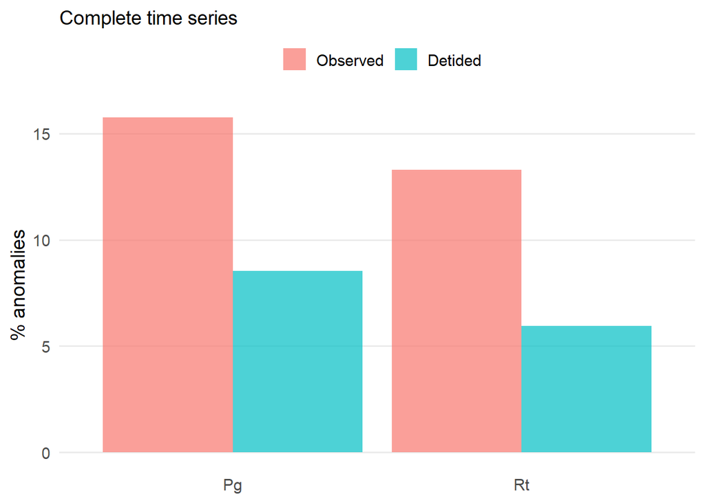

```r
ggplot(anomcmp, aes(x = var, y = val, fill = name)) +
  geom_bar(stat = 'identity',  position = 'dodge', alpha = 0.7) +
  thm +
  theme(axis.title.x = element_blank()) +
  labs(
    y = '% anomalies',
    subtitle = 'Complete time series'
  )
```

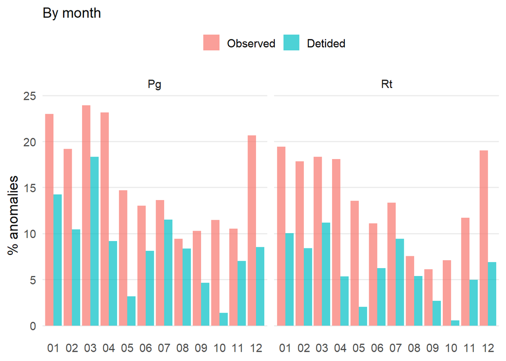

```r
ggplot(anommos, aes(x = month, y = val, fill = name)) +
  geom_bar(stat = 'identity',  position = 'dodge', alpha = 0.7) +
  facet_wrap(~var, ncol = 2) +
  thm +
  theme(axis.title.x = element_blank()) +
  labs(
    y = '% anomalies',
    subtitle = 'By month'
  )
```

For fun, let’s plot the change in anomalies from observed to detided by month.

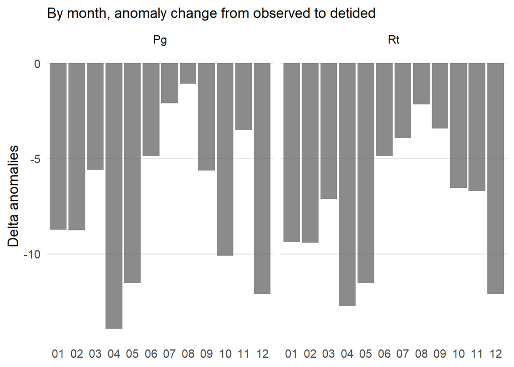

```r
toplo <- anommos %>%
  spread(name, val) %>%
  mutate(
    `Delta anomalies` = Detided - Observed
  )

ggplot(toplo, aes(x = month, y = `Delta anomalies`)) +
  geom_bar(stat = 'identity',  position = 'dodge', alpha = 0.7) +
  facet_wrap(~var, ncol = 2) +
  thm +
  theme(axis.title.x = element_blank()) +
  labs(
    subtitle = 'By month, anomaly change from observed to detided'
  )
```

Compile and summarize observed/detided metabolism results by month.

```r
apaecosum <- list(
    Observed = apaobseco,
    Detided = apadtdeco
  ) %>%
  enframe %>%
  unnest('value') %>%
  mutate(
    mo = month(Date),
    name = factor(name, levels = c('Observed', 'Detided'))
  ) %>%
  select(matches('name|mo|^Pg$|^Rt$')) %>%
  gather('var', 'val', -name, -mo) %>%
  group_by(name, mo, var) %>%
  summarise(
    ecomean = mean(val, na.rm = T),
    ecolo = t.test(val)$conf.int[1],
    ecohi = t.test(val)$conf.int[2],
    .groups = 'drop'
  )
apaecosum
```

```
## # A tibble: 48 x 6
##    name        mo var   ecomean  ecolo  ecohi
##    <fct>    <dbl> <chr>   <dbl>  <dbl>  <dbl>
##  1 Observed     1 Pg       36.4   30.1   42.7
##  2 Observed     1 Rt      -40.7  -47.1  -34.3
##  3 Observed     2 Pg       50.0   41.1   58.9
##  4 Observed     2 Rt      -56.0  -66.9  -45.2
##  5 Observed     3 Pg       40.9   31.2   50.6
##  6 Observed     3 Rt      -52.9  -63.0  -42.8
##  7 Observed     4 Pg       48.9   36.9   60.9
##  8 Observed     4 Rt      -69.0  -81.7  -56.2
##  9 Observed     5 Pg      116.   102.   130.
## 10 Observed     5 Rt     -130.  -144.  -116.
## # ... with 38 more rows
```

Make a plot of the summaries.

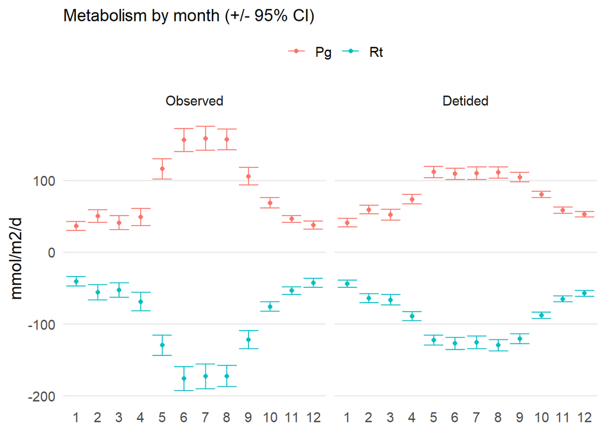

```r
ggplot(apaecosum, aes(x = factor(mo), y = ecomean, color = var)) +
  geom_errorbar(aes(ymin = ecolo, ymax = ecohi)) +
  geom_point() +
  facet_wrap(~name) +
  thm +
  labs(
    y = 'mmol/m2/d',
    x = NULL,
    subtitle = 'Metabolism by month (+/- 95% CI)'
  )
```

According to our “rules of thumb”, detiding is assumed to be effective if the mean estimates are similar between observed and detided results, whereas the variance is expected to decrease. Long-term averages (e.g., at the month or longer scale) should not change dramatically with detiding because tidal advection acts primarily at shorter time scales. As a result, noise (or variance) of the estimates will be reduced, but overall rates (means) should be similar between results. Changes in averages may suggest over-smoothing has occurred with detiding.

The plots show mean and standard deviation of production and respiration between observed and detided results. The estimates are grouped by season (as quarters) with 1:1 shown as dashed lines and regressions shown as blue lines.

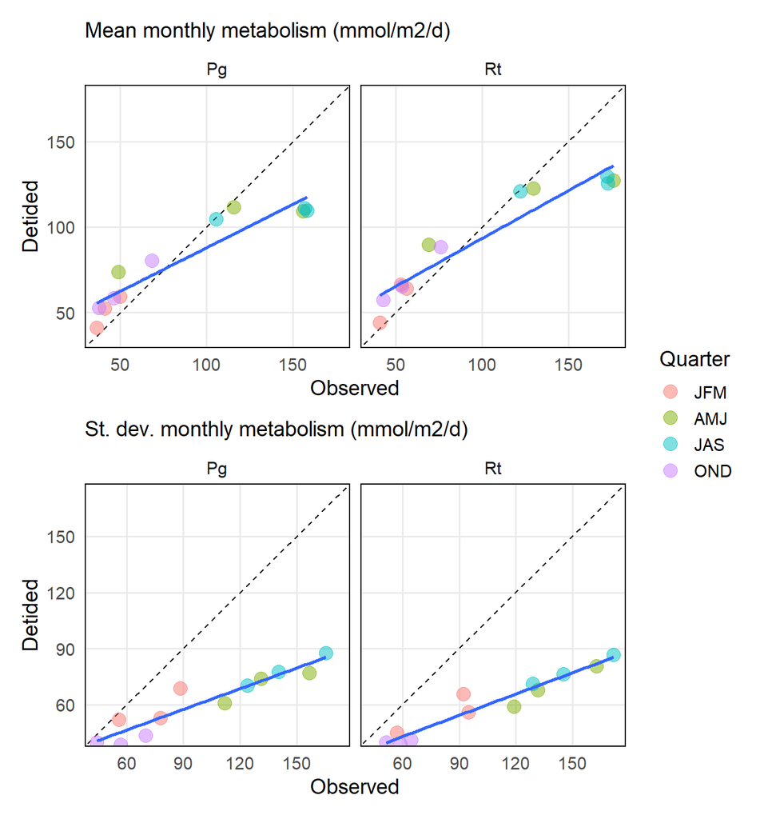

```r
# monthly mean and sd metab
meansdmos <- list(
    'Observed' = metevalobs$mos,
    'Detided' = metevaldtd$mos
  ) %>%
  enframe %>%
  unnest('value') %>%
  select(matches('name|sd|mean|month')) %>%
  gather('var', 'val', -name, -month)%>%
  mutate(
    var = gsub('Pg$', ' Pg', var),
    var = gsub('Rt$', ' Rt', var),
    name = factor(name, levels = c('Observed', 'Detided')),
    val = case_when(
      var == c('mean Rt') ~ abs(val),
      T ~ val
    ),
    qrt = case_when(
      month %in% c('01', '02', '03') ~ 'JFM',
      month %in% c('04', '05', '06') ~ 'AMJ',
      month %in% c('07', '08', '09') ~ 'JAS',
      month %in% c('10', '11', '12') ~ 'OND',
    ),
    qrt = factor(qrt, levels = c('JFM', 'AMJ', 'JAS', 'OND'))
  ) %>%
  spread(name, val) %>%
  separate(var, c('stat', 'var'))

toplo1 <- meansdmos %>%
  filter(stat == 'mean')
toplo2 <- meansdmos %>%
  filter(stat == 'sd')
rng1 <- toplo1 %>%
  pull(Observed, Detided) %>%
  range
rng2 <- toplo2 %>%
  pull(Observed, Detided) %>%
  range

p1 <- ggplot(toplo1, aes(x = Observed, y = Detided)) +
  geom_abline(intercept = 0, slope = 1, linetype = 'dashed') +
  geom_point(size = 4, alpha = 0.5, aes(color = qrt)) +
  geom_smooth(method = 'lm', se = F) +
  facet_wrap(~var) +
  coord_cartesian(xlim = rng1, ylim = rng1) +
  labs(
    subtitle = 'Mean monthly metabolism (mmol/m2/d)',
    color = 'Quarter'
  )
p2 <- ggplot(toplo2, aes(x = Observed, y = Detided)) +
  geom_abline(intercept = 0, slope = 1, linetype = 'dashed') +
  geom_point(size = 4, alpha = 0.5, aes(color = qrt)) +
  geom_smooth(method = 'lm', se = F) +
  facet_wrap(~var) +
  coord_cartesian(xlim = rng2, ylim = rng2) +
  labs(
    subtitle = 'St. dev. monthly metabolism (mmol/m2/d)',
    color = 'Quarter'
  )

p1 + p2 + plot_layout(ncol = 1, guides = 'collect') &
  thm +
  theme(
    panel.border = element_rect(fill = NA),
    panel.grid.major.x = element_line(),
    legend.position = 'right',
    legend.title = element_text()
  )
```

The summer months are pretty suspect for the detided results. Looking at the results from the `evalcor` function suggests that this is a bad time for detiding. But then again, so are the winter months…

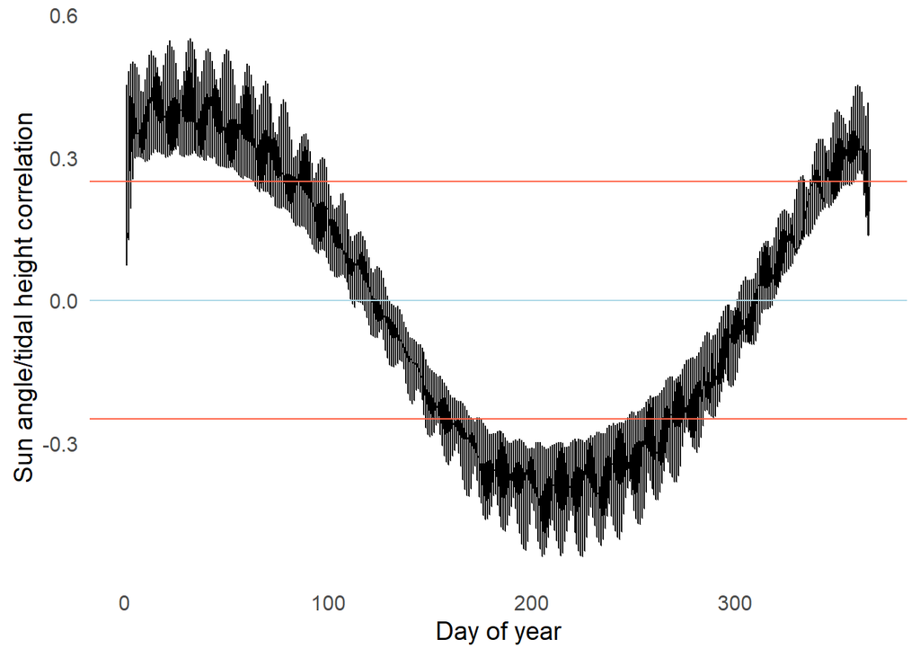

```r
toplo <- apaobs %>%
  mutate(
    dy = yday(DateTimeStamp),
    yr = year(DateTimeStamp)
  )
ggplot(toplo, aes(x = dy, y = cordat)) +
  geom_line() +
  geom_hline(yintercept = 0, col = 'lightblue') +
  geom_hline(yintercept = 0.25, col = 'tomato1') +
  geom_hline(yintercept = -0.25, col = 'tomato1') +
  thm +
  theme(
    panel.grid.major.y = element_blank()
  ) +
  labs(
    x = 'Day of year',
    y = 'Sun angle/tidal height correlation'
  )
```

We can dig deeper to evaluate associations of production with PAR, both to evaluate differences in detided and observed DO and to understand the potential role of daily PAR intensity with anomalies. First we summarize PAR on the daily scale to combine with the metabolism estimates. For the weighted regression results, there’s a column called `solar_period` that indicated whether a time step was during the night (`sunset`) or day (`sunrise`). We filter only the `sunrise` time period, then take the average within each day.

```r
apapar <- apadtd %>%
  filter(solar_period == 'sunrise') %>%
  mutate(
    Date = as.Date(DateTimeStamp)
  ) %>%
  group_by(Date) %>%
  summarise(
    `PAR mean` = mean(PAR, na.rm = T) * day_hrs * 4, # convert PAR to mmol/m2/d (hourly obs is mmol/m2/0.25hr, so x 4 x day hours)
    .groups = 'drop'
  )
apapar
```

```
## # A tibble: 58,636 x 2
##    Date       `PAR mean`
##    <date>          <dbl>
##  1 2006-01-01      8141.
##  2 2006-01-01      8141.
##  3 2006-01-01      8141.
##  4 2006-01-01      8141.
##  5 2006-01-01      8141.
##  6 2006-01-01      8141.
##  7 2006-01-01      8141.
##  8 2006-01-01      8141.
##  9 2006-01-01      8141.
## 10 2006-01-01      8141.
## # ... with 58,626 more rows
```

A plot of average daily PAR over time.

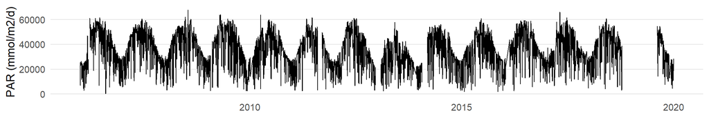

```r
ggplot(apapar, aes(x = Date, y = `PAR mean`)) +
  geom_line() +
  thm +
  labs(
    x = NULL,
    y = 'PAR (mmol/m2/d)'
  )
```

Now we combine with the metabolism observed and detided metabolism estimates.

```r
apaeco <- list(
    Observed = apaobseco,
    Detided = apadtdeco
  ) %>%
  enframe %>%
  unnest('value') %>%
  left_join(apapar, by = 'Date') %>%
  mutate(
    name = factor(name, levels = c('Observed', 'Detided'))
  )
apaeco
```

```
## # A tibble: 117,314 x 8
##    name     Date          Pg    Rt   NEM Pg_vol Rt_vol `PAR mean`
##    <fct>    <date>     <dbl> <dbl> <dbl>  <dbl>  <dbl>      <dbl>
##  1 Observed 2005-12-31   NA    NA   NA     NA     NA          NA
##  2 Observed 2006-01-01  118. -168. -49.2   54.6  -77.2      8141.
##  3 Observed 2006-01-01  118. -168. -49.2   54.6  -77.2      8141.
##  4 Observed 2006-01-01  118. -168. -49.2   54.6  -77.2      8141.
##  5 Observed 2006-01-01  118. -168. -49.2   54.6  -77.2      8141.
##  6 Observed 2006-01-01  118. -168. -49.2   54.6  -77.2      8141.
##  7 Observed 2006-01-01  118. -168. -49.2   54.6  -77.2      8141.
##  8 Observed 2006-01-01  118. -168. -49.2   54.6  -77.2      8141.
##  9 Observed 2006-01-01  118. -168. -49.2   54.6  -77.2      8141.
## 10 Observed 2006-01-01  118. -168. -49.2   54.6  -77.2      8141.
## # ... with 117,304 more rows
```

Plotting Pg vs PAR mean may be telling.

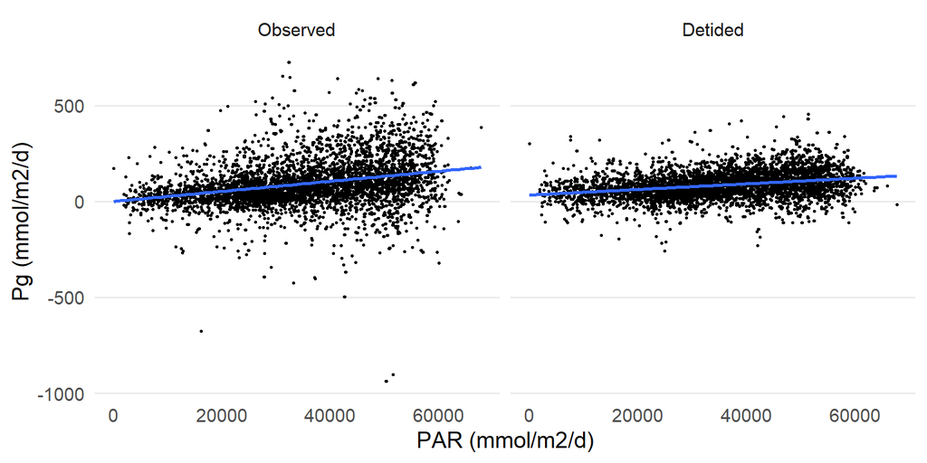

```r
ggplot(apaeco, aes(x = `PAR mean`, y = Pg)) +
  geom_point(size = 0.5, alpha = 0.6) +
  facet_wrap(~ name, ncol = 2) +
  thm +
  geom_smooth(method = 'lm') +
  labs(
    x = 'PAR (mmol/m2/d)',
    y = 'Pg (mmol/m2/d)'
  )
```

Another way to look at it is binning the PAR values into categories to see if there’s an association of anomalous values with different ranges of PAR. Below we bin PAR into thirds by the different summary metrics.

```r
toplo <- apaeco %>%
  select(name, Date, Pg, `PAR mean`) %>%
  filter(!is.na(`PAR mean`)) %>%
  mutate(
    `PAR level` = cut(`PAR mean`, breaks = c(-Inf, quantile(`PAR mean`, c(0.33, 0.66), na.rm = T), Inf), labels = c('lo', 'md', 'hi'))
  ) %>%
  group_by(name, `PAR level`) %>%
  summarise(
    `% anomalies` = 100 * sum(Pg < 0, na.rm = T) / n(),
    .groups = 'drop'
  )
toplo
```

```
## # A tibble: 6 x 3
##   name     `PAR level` `% anomalies`
##   <fct>    <fct>               <dbl>
## 1 Observed lo                  19.6
## 2 Observed md                  11.8
## 3 Observed hi                  11.8
## 4 Detided  lo                  11.3
## 5 Detided  md                   6.24
## 6 Detided  hi                   6.28
```

And a plot of the results.

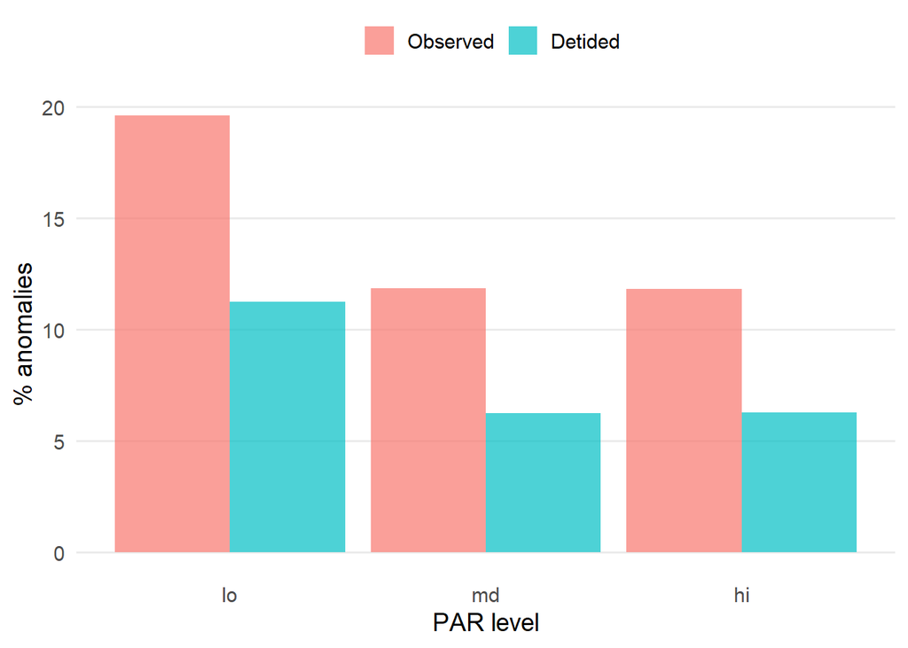

```r
ggplot(toplo, aes(x = `PAR level`, y = `% anomalies`, fill = name)) +
  geom_bar(stat = 'identity', position = 'dodge', alpha = 0.7) +
  thm
```

And lastly, repeating the analysis by season because of seasonal variation in PAR and metabolic rates.

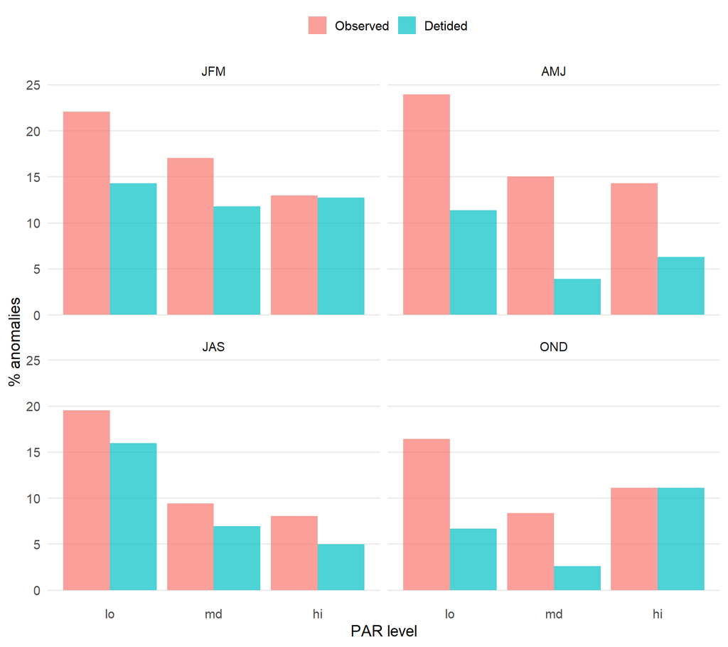

```r
toplo <- apaeco %>%
  select(name, Date, Pg, `PAR mean`) %>%
  filter(!is.na(`PAR mean`)) %>%
  mutate(
    qrt = quarter(Date),
    qrt = factor(qrt, levels = c('1', '2', '3', '4'), labels = c('JFM', 'AMJ', 'JAS', 'OND'))
  ) %>%
  mutate(
    `PAR level` = cut(`PAR mean`, breaks = c(-Inf, quantile(`PAR mean`, c(0.33, 0.66), na.rm = T), Inf), labels = c('lo', 'md', 'hi'))
  ) %>%
  group_by(name, qrt, `PAR level`) %>%
  summarise(
    `% anomalies` = 100 * sum(Pg < 0, na.rm = T) / n(),
    .groups = 'drop'
  )
ggplot(toplo, aes(x = `PAR level`, y = `% anomalies`, fill = name)) +
  geom_bar(stat = 'identity', position = 'dodge', alpha = 0.7) +
  facet_wrap(~ qrt) +
  thm
```

## Evaluate sun angle and tidal correlations

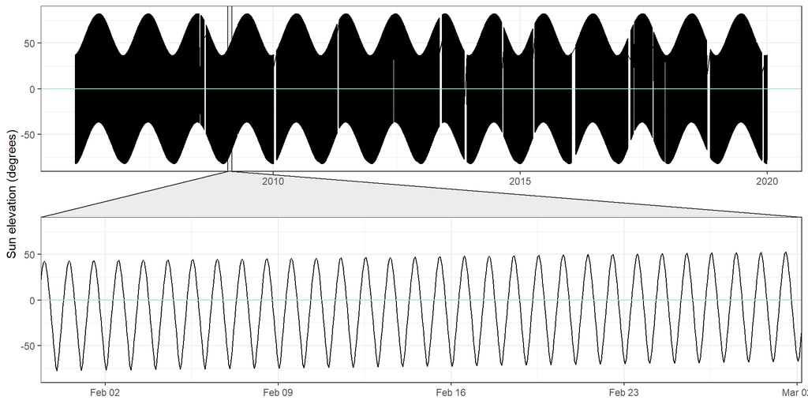

```r
# site metadata
locs <- SWMPr::stat_locs %>%
  filter(station_code == 'apacp')
lat <- locs$latitude
long <- locs$longitude

# get sun elevation angle
apasun <- apaobs %>%
  mutate(
    sunang = sunAngle(DateTimeStamp, longitude = long, latitude = lat)$altitude,
    Date = as.Date(DateTimeStamp)
  )

# plot
dts1 <- ymd_hms(c('2009-02-01 00:00:00','2009-03-01 00:00:00'))
dts2 <- as.Date(c('2009-08-01 00:00:00','2009-09-01 00:00:00'))
p <- ggplot(apasun, aes(x = DateTimeStamp, y = sunang)) +
  geom_line() +
  geom_hline(yintercept = 0, color = 'lightblue') +
  theme_bw() +
  labs(
    x = NULL,
    y = 'Sun elevation (degrees)'
  )

p + facet_zoom(x = DateTimeStamp >= dts1[1] & DateTimeStamp <= dts1[2], zoom.size = 1)
```

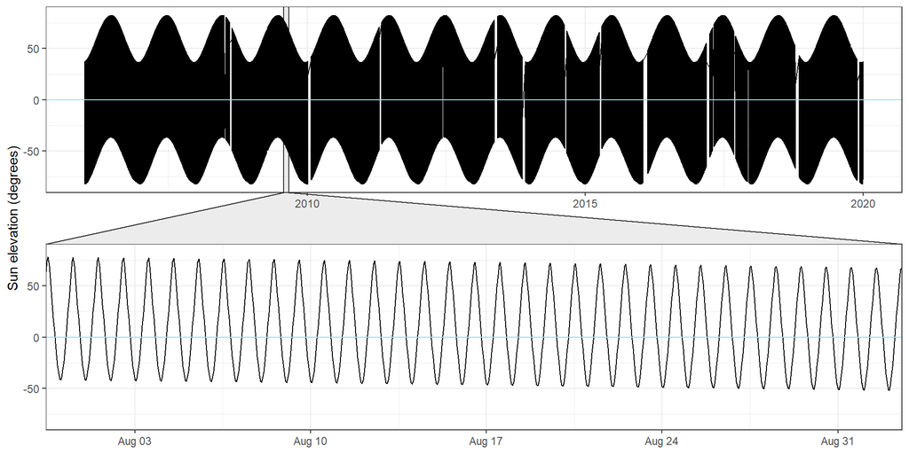

```r
p + facet_zoom(x = DateTimeStamp >= dts2[1] & DateTimeStamp <= dts2[2], zoom.size = 1)
```

Maybe we should foor the sun elevation at zero?

Now let’s look at the tidal harmonics using the oce R package and the tidem function to predict major tidal harmonics.

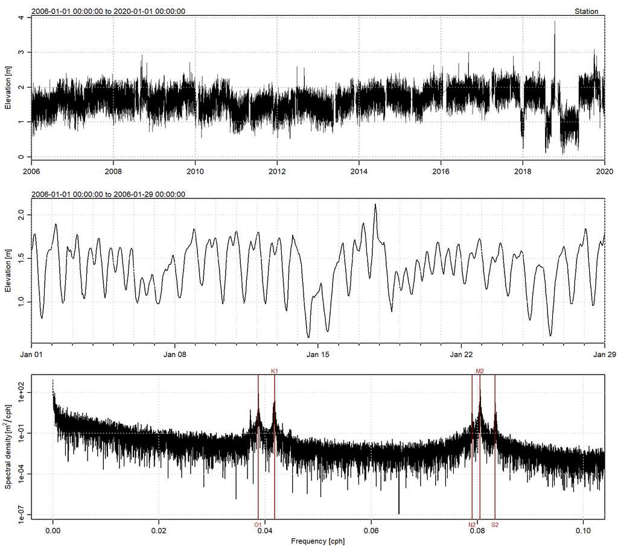

```r
datsl <- as.sealevel(elevation = apaobs$Tide, time = apaobs$DateTimeStamp)
plot(datsl)
```

We want to predict the major diurnal and semidiurnal components, plus the solar annual constituent.

```r
# tidal components to estimate
constituents <- c('M2', 'S2', 'K1', 'O1', 'SA')

# loop through tidal components, predict each with tidem
preds <- sapply(constituents, function(x){

  mod <- tidem(t = datsl, constituent = x)
  pred <- predict(mod)
  pred - mean(pred)

})
```

Here are the major diurnal/semidiurnal components for the same month slices from the sun angle plot.

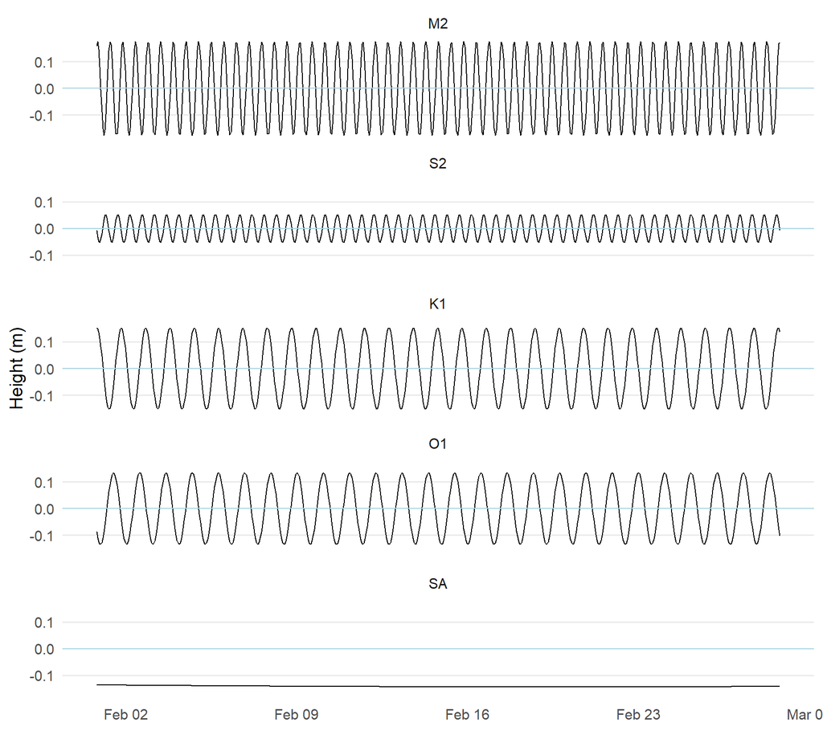

```r
# prep for plot
toplo <- preds %>%
  data.frame %>%
  mutate(DateTimeStamp = apaobs$DateTimeStamp) %>%
  gather('component', 'estimate', -DateTimeStamp) %>%
  mutate(component = factor(component, level = c('Estimated', constituents)))

toplo1 <- toplo %>%
  filter(DateTimeStamp >= dts1[1] & DateTimeStamp <= dts1[2])
toplo2 <- toplo %>%
  filter(DateTimeStamp >= dts2[1] & DateTimeStamp <= dts2[2])

ggplot(toplo1, aes(x = DateTimeStamp, y = estimate, group = component)) +
  geom_line() +
  geom_hline(yintercept = 0, color = 'lightblue') +
  facet_wrap(~component, ncol = 1) +
  thm +
  labs(
    x = NULL,
    y = 'Height (m)'
  )
```

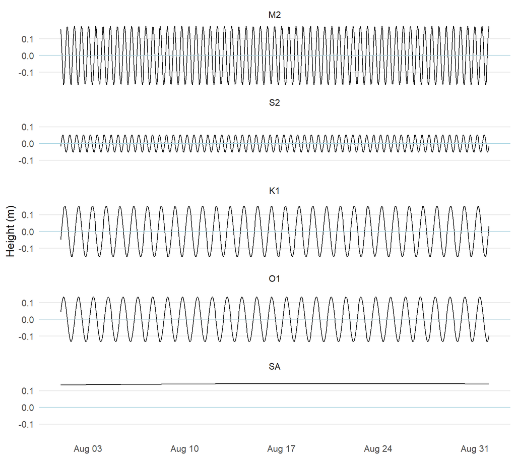

```r
ggplot(toplo2, aes(x = DateTimeStamp, y = estimate, group = component)) +
  geom_line() +
  geom_hline(yintercept = 0, color = 'lightblue') +
  facet_wrap(~component, ncol = 1) +
  thm +
  labs(
    x = NULL,
    y = 'Height (m)'
  )
```

Looking only at the solar annual component.

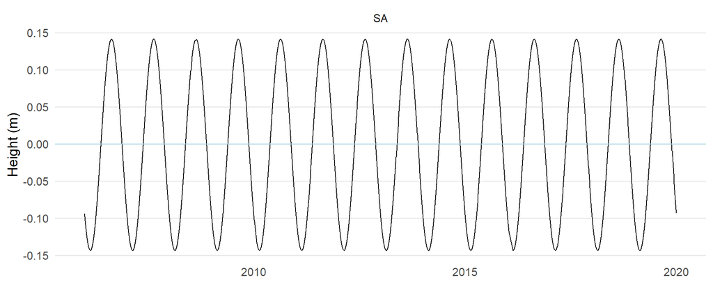

```r
toplo3 <- toplo %>%
  filter(component %in% 'SA')

ggplot(toplo3, aes(x = DateTimeStamp, y = estimate, group = component)) +
  geom_line() +
  geom_hline(yintercept = 0, color = 'lightblue') +
  facet_wrap(~component, ncol = 1) +
  thm +
  labs(
    x = NULL,
    y = 'Height (m)'
  )
```

## Half-baked conclusions

- Detiding removes more anamolous estimates in the cooler months.
- Mid-summer reduction Pg is suspect, likely related to over-smoothing from weighted regression
- More anamolous estimates seem to occur at lower PAR values, detiding occurs across all PAR values
- Need to better understand the `evalcor` function - do we floor the sun elevation angles at zero? Is it related to the SA component?